# Activity Prediction Assignment

Jamila Bano

2023-10-11

## Overview

This report will predict the manner an exercise was performed by building a machine learning model using the training and test datasets provided for assignment.Classe variable will be predicted. This report will include details on how model is built, how corss-validation is used,out of sample error and choices made.

## Data Loading and Cleaning

First load the libraries to be used. Then load and read the training and test dataset and checking structure of data

```r
library(readr)
library(rpart)
library(rpart.plot)
library(dplyr)
library(corrplot)
library(caret)
url_train<- "https://d396qusza40orc.cloudfront.net/predmachlearn/pml-training.csv"
url_test<- "https://d396qusza40orc.cloudfront.net/predmachlearn/pml-testing.csv"
download.file(url_train, destfile = "train_Data.csv")
download.file(url_test, destfile = "test_Data.csv")
dat_train = read.csv("train_Data.csv")
dat_test = read.csv("test_Data.csv")
```

## EDA

```r
str(dat_train)
summary(dat_train)
dim(dat_train)
```

Now checking variables with zero variance and removing from the data.

```r
zero_index<-nearZeroVar(dat_train)
copy_train<- dat_train
new_train<-copy_train[,-nearZeroVar(copy_train)]
```

Checking for variables having more thhan 95% values missing and removing such columns.First 6 columns used for identification are also being removed.

```r
col_check<- (colSums(is.na(new_train)) > 0.95*nrow(new_train)) #95% threshhold
null_col<-which(col_check)
new_train <- subset(new_train, select = -c(null_col))
sub_new_train<- subset(new_train,select=c(7:59))
```

## Creating training and test data

Data is further created into partitions

```r
inTrain<-createDataPartition(y=sub_new_train$classe,p=0.7,list = FALSE)
training<- sub_new_train[inTrain,]
testing<- sub_new_train[-inTrain,]
```

## Cross Validation

cross validation is used within the training set. it is further split into training and test set to improve the model fit.

## EDA Correlation

Variables are checked for correlation having more than 95% corelation. Since these arre 12 variables out of 52 PCA will not be done to further reduce the number of predictors.

```r
M<- abs(cor(training[,-53]))
diag(M)<- 0
length(which(M>0.95,arr.ind = T))
```

```
## [1] 24
```

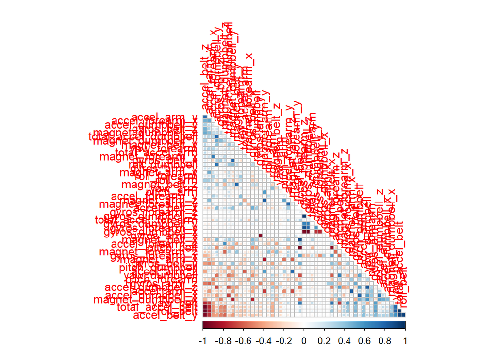

```r
corrplot(cor(training[,-53]), method = 'square', order = 'FPC', type = 'lower', diag = FALSE)
```

## Model Selection

```r
fitControl <- trainControl(method='cv', number = 3)
```

## Decision Trees

First model is decision trees

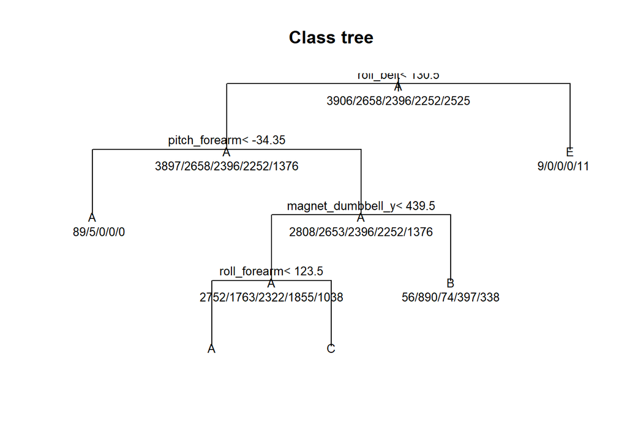

```r
mod_rpart<-train(classe~.,data=training,method='rpart',trControl=fitControl)
plot(mod_rpart$finalModel,uniform = TRUE,main='Class tree')
text(mod_rpart$finalModel,use.n = TRUE,all=TRUE,cex=0.8)
```

```r
pred_rpart<- predict(mod_rpart,testing)
confusionMatrix(pred_rpart,as.factor(testing$classe))
```

```
## Confusion Matrix and Statistics
##
##           Reference
## Prediction    A    B    C    D    E
##          A 1520  470  470  419  163
##          B   25  396   34  171  148
##          C  124  273  522  374  289
##          D    0    0    0    0    0
##          E    5    0    0    0  482
##
## Overall Statistics
##
##                Accuracy : 0.4962
##                  95% CI : (0.4833, 0.509)
##     No Information Rate : 0.2845
##     P-Value [Acc > NIR] : < 2.2e-16
##
##                   Kappa : 0.3418
##
##  Mcnemar's Test P-Value : NA
##
## Statistics by Class:
##
##                      Class: A Class: B Class: C Class: D Class: E
## Sensitivity            0.9080  0.34767   0.5088   0.0000  0.44547
## Specificity            0.6386  0.92035   0.7818   1.0000  0.99896
## Pos Pred Value         0.4997  0.51163   0.3300      NaN  0.98973
## Neg Pred Value         0.9458  0.85463   0.8829   0.8362  0.88885
## Prevalence             0.2845  0.19354   0.1743   0.1638  0.18386
## Detection Rate         0.2583  0.06729   0.0887   0.0000  0.08190
## Detection Prevalence   0.5169  0.13152   0.2688   0.0000  0.08275
## Balanced Accuracy      0.7733  0.63401   0.6453   0.5000  0.72222
```

## Random Forest

```r
mod_rf <- train(classe ~ ., data=training, method = "rf")
mod_rf$finalModel
```

```
##
## Call:
##  randomForest(x = x, y = y, mtry = param$mtry)
##                Type of random forest: classification
##                      Number of trees: 500
## No. of variables tried at each split: 2
##
##         OOB estimate of  error rate: 0.67%
## Confusion matrix:
##      A    B    C    D    E  class.error
## A 3903    3    0    0    0 0.0007680492
## B   13 2641    4    0    0 0.0063957863
## C    0   21 2374    1    0 0.0091819699
## D    0    0   41 2209    2 0.0190941385
## E    0    0    0    7 2518 0.0027722772
```

```r
pred_rf<- predict(mod_rf,testing)
confusionMatrix(pred_rf,as.factor(testing$classe))
```

```
## Confusion Matrix and Statistics
##
##           Reference
## Prediction    A    B    C    D    E
##          A 1673    4    0    0    0
##          B    1 1135    6    0    0
##          C    0    0 1018   16    0
##          D    0    0    2  948    2
##          E    0    0    0    0 1080
##
## Overall Statistics
##
##                Accuracy : 0.9947
##                  95% CI : (0.9925, 0.9964)
##     No Information Rate : 0.2845
##     P-Value [Acc > NIR] : < 2.2e-16
##
##                   Kappa : 0.9933
##
##  Mcnemar's Test P-Value : NA
##
## Statistics by Class:
##
##                      Class: A Class: B Class: C Class: D Class: E
## Sensitivity            0.9994   0.9965   0.9922   0.9834   0.9982
## Specificity            0.9991   0.9985   0.9967   0.9992   1.0000
## Pos Pred Value         0.9976   0.9939   0.9845   0.9958   1.0000
## Neg Pred Value         0.9998   0.9992   0.9984   0.9968   0.9996
## Prevalence             0.2845   0.1935   0.1743   0.1638   0.1839
## Detection Rate         0.2843   0.1929   0.1730   0.1611   0.1835
## Detection Prevalence   0.2850   0.1941   0.1757   0.1618   0.1835
## Balanced Accuracy      0.9992   0.9975   0.9945   0.9913   0.9991
```

## Boost Model

```r
mod_boost<-train(classe ~ . ,trControl=fitControl,method="gbm", data=training,verbose=FALSE)
pred_boost<- predict(mod_boost,testing)
confusionMatrix(pred_boost,as.factor(testing$classe))
```

```
## Confusion Matrix and Statistics
##
##           Reference
## Prediction    A    B    C    D    E
##          A 1653   34    0    0    3
##          B   14 1076   38    2    8
##          C    4   26  976   41    9
##          D    3    2   12  915   17
##          E    0    1    0    6 1045
##
## Overall Statistics
##
##                Accuracy : 0.9626
##                  95% CI : (0.9575, 0.9673)
##     No Information Rate : 0.2845
##     P-Value [Acc > NIR] : < 2.2e-16
##
##                   Kappa : 0.9527
##
##  Mcnemar's Test P-Value : 1.919e-08
##
## Statistics by Class:
##
##                      Class: A Class: B Class: C Class: D Class: E
## Sensitivity            0.9875   0.9447   0.9513   0.9492   0.9658
## Specificity            0.9912   0.9869   0.9835   0.9931   0.9985
## Pos Pred Value         0.9781   0.9455   0.9242   0.9642   0.9933
## Neg Pred Value         0.9950   0.9867   0.9896   0.9901   0.9923
## Prevalence             0.2845   0.1935   0.1743   0.1638   0.1839
## Detection Rate         0.2809   0.1828   0.1658   0.1555   0.1776
## Detection Prevalence   0.2872   0.1934   0.1794   0.1613   0.1788
## Balanced Accuracy      0.9893   0.9658   0.9674   0.9711   0.9822
```

After checking the accuracy of all three models, Random forest model has the best accuracy and it will be selected as final model for prediction.

## Original Test data Prediction

```
##  [1] B A B A A E D B A A B C B A E E A B B B
## Levels: A B C D E
```